# PEcAn Benchmarking and Validation Framework Tutorial

PEcAn Development Team

2026-09-13

## Introduction

The `PEcAn.benchmark` toolkit provides a modular framework for aligning, evaluating, and visualizing ecosystem model predictions against observational benchmark datasets.

## 1. Input Data Schemas and Ensemble Representation

The validation toolkit expects model outputs and observations in standardized formats.

### Model Ensemble Output (EFI Long Format)

Model ensemble outputs follow the EFI (Ecological Forecasting Initiative) standard long format:

- `datetime`: Timestamp string (e.g. `"2020-01-01 00:00:00"`).
- `site_id`: Site identifier (e.g. `"socs_sys1"` or `"US-Ha1"`).
- `parameter`: Integer index or member ID for each ensemble member (e.g. `1, 2, ..., N`).
- `variable`: CF/PEcAn standard variable name (e.g. `"TotSoilCarb"`, `"NEE"`, `"GPP"`).
- `prediction`: Model output numeric prediction value.

### Observation Dataset

Observational data require at minimum: * `date` / `time`: Timestamp (POSIXct or parseable string). * `obs_mean` / `obvs`: Observational numeric mean value. * `obs_sd` / `obvs_sd` (optional): Observational standard deviation / measurement error. * `site_id` / `site` (optional): Site identifier matching the model dataset.

## 2. Statistical Error Model and Fixture Generation

To evaluate model metrics against known true error parameterizations, simulated observations can be generated using an explicit statistical error model:

$$o_{v,t} = m_{v,t} + S_v(\beta_v +
\epsilon_{v,t}), \qquad \epsilon_{v,t} \sim N(0, \tau_v^2)$$

Where: * $o_{v,t}$ is the simulated observation for variable $v$ at time $t$; * $m_{v,t}$ is the ensemble mean prediction; * $S_v$ is the scale factor (standard deviation of the ensemble mean); * $\beta_v$ is the relative bias parameter (e.g. $0.30$, representing relative bias of $30\%$); * $\tau_v$ is the relative random error standard deviation (e.g. $0.50$, representing random noise equal to $50\%$ of variability).

### R Simulation Code (Reference)

```r
# Side-note: R snippet used to generate observation fixtures from an error model
set.seed(3)
output_scale <- stats::sd(ensemble_mean)

relative_bias  <- 0.3 # 30% relative bias
relative_error <- 0.5 # 50% relative error noise

simulated_observation <- ensemble_mean +
  output_scale * (
    relative_bias +
      stats::rnorm(length(ensemble_mean), mean = 0, sd = relative_error)
  )
```

In `PEcAn.benchmark`, precomputed text fixtures (`small_salinas_ensemble.csv` and `small_salinas_obs.csv`) are provided in package `extdata` for fast, reproducible offline testing.

## 3. Data Intake, Reshaping, and Alignment

We load the package and read the precomputed fixtures:

```r
library(PEcAn.benchmark)

# Path to built-in simulation fixtures
extdata_dir <- system.file("extdata", package = "PEcAn.benchmark")
if (extdata_dir == "" || !file.exists(file.path(extdata_dir, "small_salinas_ensemble.csv"))) {
  extdata_dir <- file.path(getwd(), "../inst/extdata")
}

model_csv <- file.path(extdata_dir, "small_salinas_ensemble.csv")
obs_csv   <- file.path(extdata_dir, "small_salinas_obs.csv")

raw_model <- read.csv(model_csv)
raw_obs   <- read.csv(obs_csv)

head(raw_model[, c("datetime", "site_id", "parameter", "variable", "prediction")])
```

```
#>               datetime   site_id parameter    variable prediction
#> 1 2010-01-01T00:00:00Z socs_sys1         1 TotSoilCarb      9.148
#> 2 2010-02-01T00:00:00Z socs_sys1         1 TotSoilCarb      8.374
#> 3 2010-03-01T00:00:00Z socs_sys1         1 TotSoilCarb      8.745
#> 4 2010-04-01T00:00:00Z socs_sys1         1 TotSoilCarb      8.853
#> 5 2010-05-01T00:00:00Z socs_sys1         1 TotSoilCarb      8.762
#> 6 2010-06-01T00:00:00Z socs_sys1         1 TotSoilCarb      8.558
```

```r
head(raw_obs[, c("date", "site_id", "variable", "obs_mean", "obs_sd")])
```

```
#>                   date   site_id    variable obs_mean obs_sd
#> 1 2010-11-15T00:00:00Z socs_sys1 TotSoilCarb      8.9   0.40
#> 2 2010-11-15T00:00:00Z socs_sys2 TotSoilCarb      9.1   0.45
#> 3 2011-11-15T00:00:00Z socs_sys1 TotSoilCarb      8.7   0.38
#> 4 2011-11-15T00:00:00Z socs_sys2 TotSoilCarb      8.8   0.42
```

### Reshaping EFI Long Data to Ensemble Matrix (`efi_long_to_array`)

To retain individual member trajectory information for spaghetti plots and probabilistic metrics (like CRPS), we reshape the long model dataset into an ensemble matrix:

```r
# Reshape EFI long format dataframe to a (time x member) matrix
ens_mat <- efi_long_to_array(raw_model, var = "TotSoilCarb", site = "socs_sys1")

# Summary data frame with ensemble mean and 90% prediction intervals
model_summary <- data.frame(
  time = attr(ens_mat, "time"),
  value = rowMeans(ens_mat, na.rm = TRUE),
  model_q05 = apply(ens_mat, 1, quantile, probs = 0.05, na.rm = TRUE),
  model_q95 = apply(ens_mat, 1, quantile, probs = 0.95, na.rm = TRUE),
  site = "socs_sys1"
)

# Observation data frame
obs_filtered <- raw_obs[raw_obs$site_id == "socs_sys1" & raw_obs$variable == "TotSoilCarb", ]
obs_summary <- data.frame(
  time = as.POSIXct(obs_filtered$date, tz = "UTC"),
  value = obs_filtered$obs_mean,
  obvs_sd = obs_filtered$obs_sd,
  site = "socs_sys1"
)
```

### Temporal Alignment (`align_by_time`)

We align model predictions and observations in time within a half-year tolerance window (for annual observation alignment):

```r
# Align model summary and observations by timestamp
aligned_df <- align_by_time(model_summary, obs_summary, tolerance_secs = 365 * 86400 / 2)

# Match ensemble matrix indices to aligned time points
aligned_indices <- match(aligned_df$time, model_summary$time)
aligned_ens_mat <- ens_mat[aligned_indices, , drop = FALSE]
attr(aligned_df, "ensemble_matrix") <- aligned_ens_mat

head(aligned_df)
```

```
#>         time  model model_q05 model_q95      site   obs_time obvs obvs_sd
#> 1 2010-11-01 9.0462    8.0106   9.93295 socs_sys1 2010-11-15  8.9    0.40
#> 2 2011-11-01 8.9321    8.2676   9.47765 socs_sys1 2011-11-15  8.7    0.38
```

## 4. Metric Calculations and Interpretation

The framework categorizes evaluation metrics into two groups:

1. **Point Metrics on Ensemble Mean**: Evaluates deterministic skill of the ensemble mean vector $\bar{m}$.
   - **BIAS / Mean Bias Error**: $\frac{1}{N}\sum (\bar{m}_i - o_i)$. Quantifies systematic over- or under-prediction.
   - **RMSE (Root Mean Squared Error)**: $\sqrt{\frac{1}{N}\sum (\bar{m}_i - o_i)^2}$. Overall magnitude of error.
   - **MAE (Mean Absolute Error)**: $\frac{1}{N}\sum |\bar{m}_i - o_i|$. L1 norm error distance.
   - **R2 (Squared Pearson Correlation)**: Coefficient of determination indicating proportion of variance explained.
2. **Spread / Probabilistic Metrics on Full Ensemble**: Evaluates prediction uncertainty and ensemble dispersion.
   - **COVERAGE (Prediction Interval Coverage)**: Fraction of observations falling within the 90% ensemble prediction interval $[q_{05}, q_{95}]$.
   - **CRPS (Continuous Ranked Probability Score)**: Evaluates full predictive probability distribution against observations using `scoringRules::crps_sample()` (or an analytical sample score fallback).

```r
# Compute complete metric suite
metrics_results <- compute_metrics(
  aligned_df,
  metrics = c("BIAS", "RMSE", "MAE", "R2", "COVERAGE", "CRPS")
)

print(metrics_results)
```

```
#>        Site    BIAS     RMSE     MAE R2 COVERAGE     CRPS
#> 1 socs_sys1 0.18915 0.193965 0.18915  1        1 0.210625
```

### Spaghetti + Ribbon Timeseries Plot (`metric_timeseries_plot`)

Renders individual member trajectories (spaghetti) under the $q_{05}/q_{95}$ prediction ribbon alongside observations and error bars:

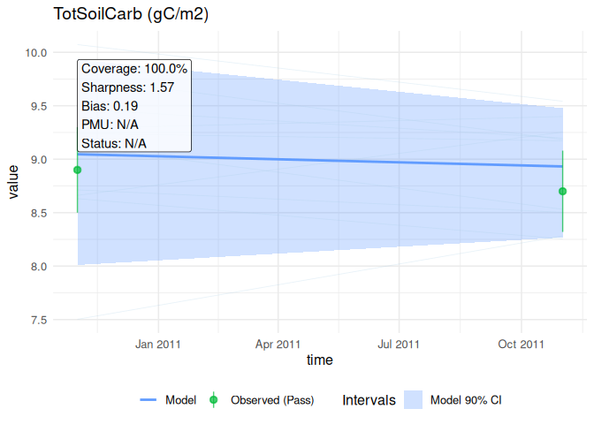

```r
p_ts <- metric_timeseries_plot(aligned_df, var = "TotSoilCarb (gC/m2)")
print(p_ts)
```

### Diagnostic Scatter Plot (`metric_scatter_plot`)

Plots observed values against predicted ensemble mean values:

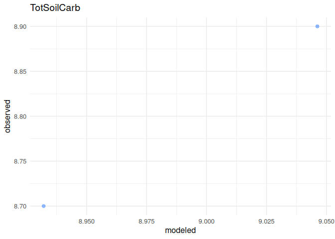

```r
p_sc <- metric_scatter_plot(aligned_df, var = "TotSoilCarb")
print(p_sc)
```

### Residual Plot (`metric_residual_plot`)

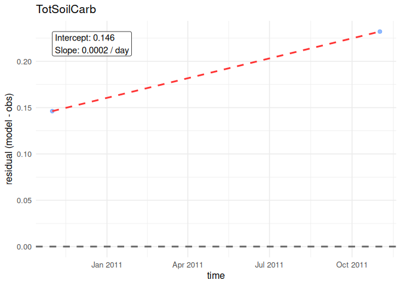

```r
p_res <- metric_residual_plot(aligned_df, var = "TotSoilCarb")
print(p_res)
```

## 6. Substituting Custom Processed Data

To evaluate your own model predictions and observations: 1. Format model predictions in EFI long format CSV (`datetime`, `site_id`, `parameter`, `variable`, `prediction`). 2. Format observations with `date`/`time` and `obs_mean`/`obvs`. 3. Use `efi_long_to_array()` to extract the ensemble matrix. 4. Pass your aligned data into `align_by_time()` and `compute_metrics()`.